# Assignment 2 Solutions

Beatrix Jones

5/5/2020

### Question 1 (5 marks for the code, 3 marks for the plot, 4 marks for sensible comments.)

Perform the linear discriminant analysis, using numeric variables only (not region or country labels) and use leave-1-out cross validation to evaluate how many discriminant functions are useful for separating the government types. You may find it useful to add 1 to the regime variable before beginning—the LDA output will label the categories 1-6, not 0-5. Provide a pairs plot of the useful discriminant scores. Are the groups well separated? If not, which are hard to distinguish? Are any discriminant scores associated with separating particular government types?

```r
library(MASS)
read.csv('governments.csv')->governments
gov.reduced<-governments[,-c(1:3)]
predictions<-matrix(NA, ncol=5, nrow=nrow(governments))
for(i in 1:nrow(governments)){
mod<-lda(factor(regime)~ . ,data=gov.reduced[-i,])
for(j in 1:5){
mod.predict<-predict(mod, newdata=gov.reduced[i,], dimen=j)
predictions[i,j]<-mod.predict$class
} }

for(i in 1:5) print(c(i,sum(governments$regime==(predictions[,i]-1)))) #this is to cope with the regimes being listed as 0-5 rather than 1-6
```

```
## [1]  1 78
## [1]  2 95
## [1]  3 94
## [1]  4 98
## [1]  5 90
```

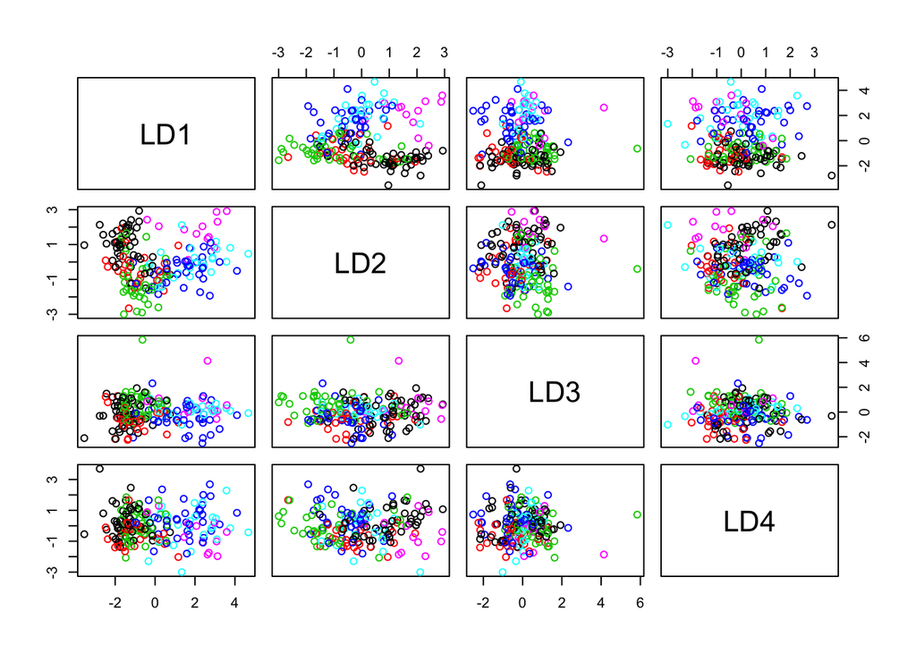

```r
mod<-lda(factor(regime)~ . ,data=gov.reduced)
mod.predict<-predict(mod, dimen=4)
pairs(mod.predict$x, col=governments$regime+1)
```

*The numbers given are the number of countries correctly classified. While the cross validated accuracy is maximized with four components, the difference between 2 and 4 components is very small and in the pairs plot LD3 and 4 look fairly useless–maybe just dicriminating a few special cases. Therfore we will use 2 components from here (OK if you carried on with 4, or chose 2 and only made the pairs plot for 2). It looks like LD1 separates the democracies from the dictatorships (well but not perfectly), while LD2 separates between the different govenments of each type, eg parlimentary vs presidential democracy, or civilian dictatorship vs monarchy. This is less effective with a lot of overlap betwen groups.*

### Question 2 (4 marks for computing the correlations, 4 marks for pretty output (names, rounding, or using “loadings” class to supress small correlations), 4 marks for sensible comments )

Compute the correlation of the useful discriminant functions with the original variables. Display the output in readable form. What are the most important variables associated with each function? Are there any variables that don’t help discriminate between the government types?

```r
var.cors<-matrix(nrow=nrow(mod$scaling), ncol=2)
governments.noreg<-gov.reduced[,-3]
rownames(var.cors)<-names(governments.noreg)
for(i in 1:15) for(j in 1:2) var.cors[i,j]<-cor(mod.predict$x[,j], governments.noreg[,i])
round(var.cors,2)
```

```
##             [,1] [,2]
## bornyear    0.27 0.05
## tenure08    0.64 0.13
## agereg     -0.21 0.46
## VAEstimate -0.92 0.25
## VAStdErr   -0.38 0.57
## PSEstimate -0.35 0.49
## PSStdErr   -0.08 0.12
## GEEstimate -0.53 0.55
## GEStdErr   -0.20 0.40
## RQEstimate -0.59 0.54
## RQStdErr   -0.31 0.49
## RLEstimate -0.56 0.66
## RLStdErr   -0.13 0.31
## CCEstimate -0.53 0.59
## CCStdErr   -0.12 0.29
```

If you wish to use the “loadings” class (optional) it looks like this:

```r
class(var.cors)<-"loadings"
print(var.cors, cutoff=0.3)  #cutoff up to you. 0.3 is about the largest it should be.
```

```
##
## Loadings:
##            [,1]   [,2]
## bornyear
## tenure08    0.642
## agereg             0.464
## VAEstimate -0.918
## VAStdErr   -0.375  0.574
## PSEstimate -0.350  0.491
## PSStdErr
## GEEstimate -0.534  0.551
## GEStdErr           0.400
## RQEstimate -0.592  0.539
## RQStdErr   -0.311  0.494
## RLEstimate -0.561  0.656
## RLStdErr           0.307
## CCEstimate -0.527  0.589
## CCStdErr
##
##                 [,1]  [,2]
## SS loadings    3.042 2.836
## Proportion Var 0.203 0.189
## Cumulative Var 0.203 0.392
```

*Almost all the variables have at least a moderate correlation with one of the discriminant functions. The exception may be “PSStdErr,” the standard error of the political stability/no violence measure. The first canonical variate is strongly correlated with “Voice and Accountability;” it seems this is a primary feature of democracies (lower on the LD1 axis). The second canonical variate had moderately high correlations with all the other estimated scores, and the age of the regime. Parlimentary democracies and monarchies are scoring the highest on these, with presidential democracies the worst.*

### Question 3 (2 marks for code, 2 marks for pretty output, 2 marks for sensible comment)

Consider the observations in “newdata.csv.” What would be the posterior probability of each regime type for these observations? Display in a readable form. These are actually data from 1996. What cautions do you have about interpreting these posterior probabilities?

```r
newdata<-read.csv('newdata2020-update.csv')
round(predict(mod, newdata=newdata, dimen=2)$posterior,2)
```

```
##      0    1    2    3    4    5
## 1 0.00 0.00 0.00 0.23 0.57 0.20
## 2 0.21 0.21 0.21 0.25 0.10 0.01
## 3 0.02 0.03 0.04 0.51 0.35 0.04
```

*The caution is that the characteristics of the regime types may have changed over time, so a (eg) military dicatorship of 2008 may look different than in 1996.*

### Question 4 (6 marks for the plots, 3 for sensible comments )

Asess the normality of the LDA scores within each regime for your “useful” components. My suggestion would be to use qqplots. How do these results influence your interpretation of your results above?

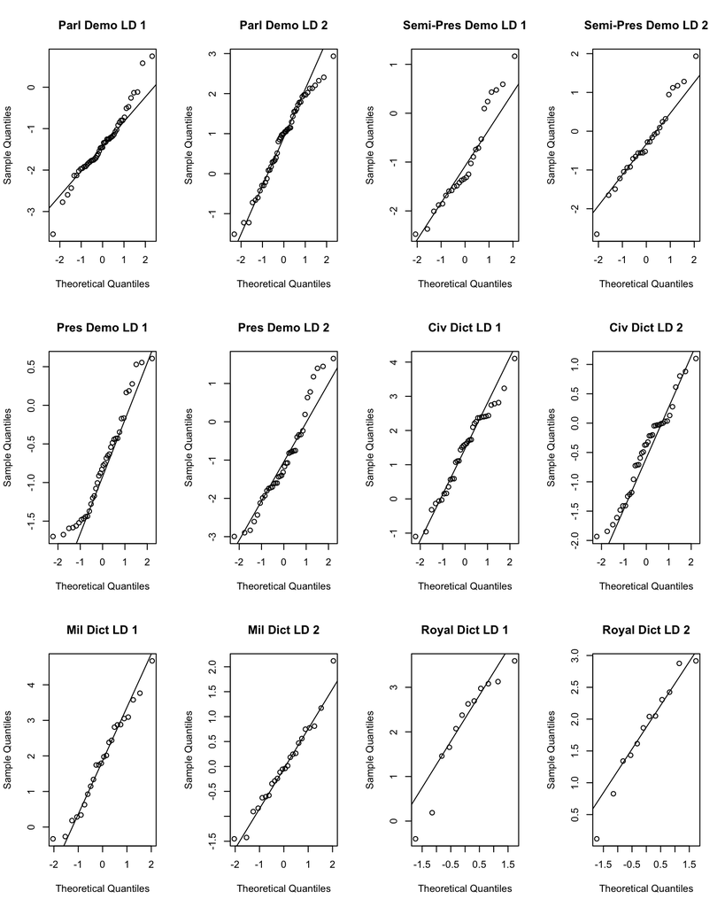

```r
par(mex=0.5, mfrow=c(3,4))
reg.names<-c("Parl Demo", "Semi-Pres Demo", "Pres Demo", "Civ Dict", "Mil Dict", "Royal Dict")
for(i in 0:5){
  for(j in 1:2){
  qqnorm(mod.predict$x[governments$regime==i,j], main=paste(c(reg.names[i+1], "LD",j), collapse=" "))
  qqline(mod.predict$x[governments$regime==i,j])}}
```

*Overall normality doesn’t look too bad, although there are some deviations in the tails. For example, look at LD1 for Parlimentary democracy–the actual distribution deviates from the line and is heavier tailed than the normal. In this situation the probability statements about Parlimentary vs another category, when LD1 is far from the meanma, may be misleading (with Parlimentary democracy more likely than predicted by the normal). Your answer should mention some deviation in the tails, and that this affects the accuracy of posterior probabilities.*

### Question 5 (4 marks for the code/classifications, 3 for the plots or summary stats addressing different variances, 4 for sensible comments on the questions. )

Try QDA for this dataset. You will need to exclude “royal dictatorship”—explain why. What situation is QDA designed for? Is there evidence that our data fall into this situation? How does the performance compare to LDA?

*QDA fits a separate covariance matrix for each category, which has to be invertible. Since we have 15 variables, the 12 observations in “Royal Dictatorship” are not sufficient to estimate an invertible covariance.*

```r
 gov.reduced<-gov.reduced[governments$regime!=5,]
 qda(regime~., data=gov.reduced, CV=TRUE)->qda.mod
 sum(qda.mod$class==gov.reduced$regime)
```

```
## [1] 89
```

```r
nrow(gov.reduced)
```

```
## [1] 174
```

```r
 table(paste("qda predict",qda.mod$class), paste("actual",gov.reduced$regime))
```

```
##
##                 actual 0 actual 1 actual 2 actual 3 actual 4
##   qda predict 0       35        8        9        4        3
##   qda predict 1        4        9        2        1        0
##   qda predict 2        6        5       17        3        3
##   qda predict 3        4        3        9       25       15
##   qda predict 4        0        1        1        4        3
```

```r
 table(paste("lda predict", predictions[,2]-1), paste("actual", governments$regime))
```

```
##
##                 actual 0 actual 1 actual 2 actual 3 actual 4 actual 5
##   lda predict 0       38       11        7        1        1        2
##   lda predict 1        1        0        0        0        0        0
##   lda predict 2        8       12       26        9        4        0
##   lda predict 3        2        2        4       19       10        2
##   lda predict 4        0        1        0        7        6        2
##   lda predict 5        0        0        1        1        3        6
```

*QDA is designed to accomodate the situation where the covariance matrices are different between groups. One way this can be violated is if the variance of any variable is different between groups. Comparison can be via a plot, or via summary stats. There are several examples of this across the 15 variables, fine to include just one or a selection. For instance, in the plot below “bornyear” has a much smaller variance for the two dictatorship regime types. Note this doesn’t guarantee QDA will outperform LDA, especially in the presence of non-normality, but indicates that it is worth trying.*

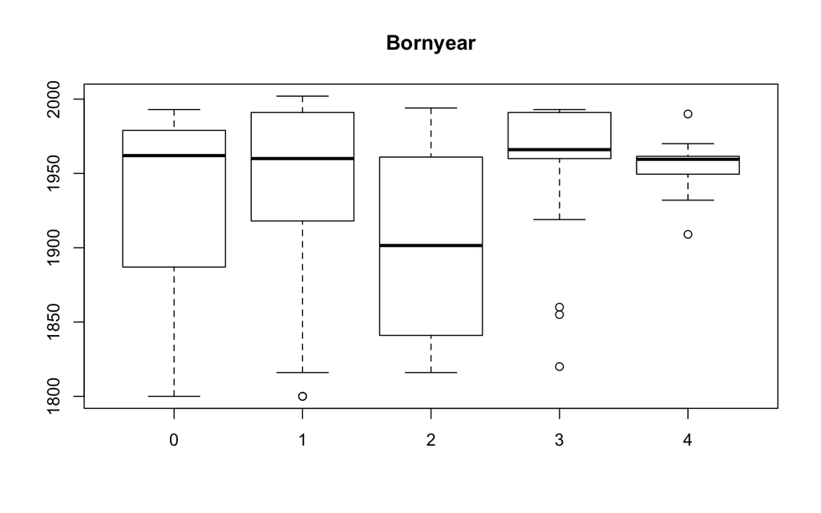

```r
boxplot(gov.reduced$bornyear~gov.reduced$regime, labels=reg.names[1:5], main="Bornyear")
```